# R Notebook

# Part 2 Solutions

```r
### Load the libraries will we need
library(readr)
library(dplyr)
library(ggplot2)
```

Read the data and check

```r
gapminder <- read_csv("raw_data/gapminder.csv")
head(gapminder)
```

| country | continent | year | lifeExp | pop | gdpPercap |
| --- | --- | --- | --- | --- | --- |
| Afghanistan | Asia | 1952 | 28.801 | 8425333 | 779.4453 |
| Afghanistan | Asia | 1957 | 30.332 | 9240934 | 820.8530 |
| Afghanistan | Asia | 1962 | 31.997 | 10267083 | 853.1007 |
| Afghanistan | Asia | 1967 | 34.020 | 11537966 | 836.1971 |
| Afghanistan | Asia | 1972 | 36.088 | 13079460 | 739.9811 |
| Afghanistan | Asia | 1977 | 38.438 | 14880372 | 786.1134 |

## In-class exercises

Create a subset of the data where the population less than a million in the year 2002

```r
filter(gapminder, pop < 1e6, year == 2002)
```

| country | continent | year | lifeExp | pop | gdpPercap |
| --- | --- | --- | --- | --- | --- |
| Bahrain | Asia | 2002 | 74.795 | 656397 | 23403.559 |
| Comoros | Africa | 2002 | 62.974 | 614382 | 1075.812 |
| Djibouti | Africa | 2002 | 53.373 | 447416 | 1908.261 |
| Equatorial Guinea | Africa | 2002 | 49.348 | 495627 | 7703.496 |
| Iceland | Europe | 2002 | 80.500 | 288030 | 31163.202 |
| Montenegro | Europe | 2002 | 73.981 | 720230 | 6557.194 |
| Reunion | Africa | 2002 | 75.744 | 743981 | 6316.165 |
| Sao Tome and Principe | Africa | 2002 | 64.337 | 170372 | 1353.092 |

Create a subset of the data where the life expectancy is greater than 75 in the years prior to 1987

```r
filter(gapminder, lifeExp > 75, year < 1987)
```

| country | continent | year | lifeExp | pop | gdpPercap |
| --- | --- | --- | --- | --- | --- |
| Canada | Americas | 1982 | 75.76 | 25201900 | 22898.79 |
| Greece | Europe | 1982 | 75.24 | 9786480 | 15268.42 |
| Hong Kong, China | Asia | 1982 | 75.45 | 5264500 | 14560.53 |
| Iceland | Europe | 1977 | 76.11 | 221823 | 19654.96 |
| Iceland | Europe | 1982 | 76.99 | 233997 | 23269.61 |
| Japan | Asia | 1977 | 75.38 | 113872473 | 16610.38 |
| Japan | Asia | 1982 | 77.11 | 118454974 | 19384.11 |
| Netherlands | Europe | 1977 | 75.24 | 13852989 | 21209.06 |
| Netherlands | Europe | 1982 | 76.05 | 14310401 | 21399.46 |
| Norway | Europe | 1977 | 75.37 | 4043205 | 23311.35 |

[output cut: 6 more lines]

Create a subset of the European data where the life expectancy is between 75 and 80 in the years 2002 or 2007.

```r
filter(gapminder, continent == "Europe", lifeExp > 75, lifeExp < 80 , year == 2002 | year == 2007)
```

| country | continent | year | lifeExp | pop | gdpPercap |
| --- | --- | --- | --- | --- | --- |
| Albania | Europe | 2002 | 75.651 | 3508512 | 4604.212 |
| Albania | Europe | 2007 | 76.423 | 3600523 | 5937.030 |
| Austria | Europe | 2002 | 78.980 | 8148312 | 32417.608 |
| Austria | Europe | 2007 | 79.829 | 8199783 | 36126.493 |
| Belgium | Europe | 2002 | 78.320 | 10311970 | 30485.884 |
| Belgium | Europe | 2007 | 79.441 | 10392226 | 33692.605 |
| Croatia | Europe | 2007 | 75.748 | 4493312 | 14619.223 |
| Czech Republic | Europe | 2002 | 75.510 | 10256295 | 17596.210 |
| Czech Republic | Europe | 2007 | 76.486 | 10228744 | 22833.309 |
| Denmark | Europe | 2002 | 77.180 | 5374693 | 32166.500 |

[output cut: 21 more lines]

Can also use the `between` function from `dplyr` and the `%in%` function

```r
filter(gapminder, continent == "Europe",
       between(lifeExp, 75,80),
       year %in% c(2002,2007))
```

Write a workflow to do the following:-

- Filter the data to include just observations from the year 2002
- Re-arrange the table so that the countries from each continent are ordered according to decreasing wealth. i.e. the wealthiest countries first
- Select all the columns apart from year
- Write the data frame out to a file in out_data/ folder

```r
# Less-efficient solution before pipes are introduced

# create out_data folder before we start (no warning given if it already exists)
dir.create("out_data", showWarnings = FALSE)

gapminder2 <- filter(gapminder, year == 2002)
gapminder3 <- arrange(gapminder2, continent, desc(gdpPercap))
gapminder4 <- select(gapminder3, -year)
write_csv(gapminder4, "out_data/gapminder_2002.csv")
```

Re-written using pipes

```r
filter(gapminder, year == 2002) %>%
  arrange(continent, desc(gdpPercap)) %>%
  select(-year) %>%
write_csv("out_data/gapminder_piped_2002.csv")
```

The violin plot is a popular alternative to the boxplot. Create a violin plot with geom_violin to visualise the differences in GDP between different continents.

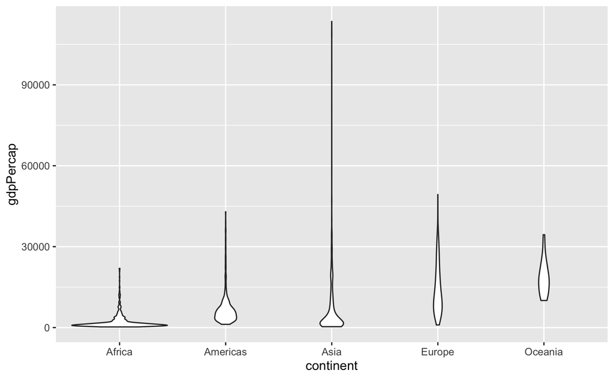

```r
ggplot(gapminder, aes(x = continent, y = gdpPercap)) + geom_violin()
```

Create a subset of the gapminder data frame containing just the rows for your country of birth

```r
# don't forget that R is case-sensitive!

uk_data <- filter(gapminder, country == "United Kingdom")
```

Has there been an increase in life expectancy over time? - visualise the trend using a scatter plot (geom_point), line graph (geom_line) or smoothed line (geom_smooth).

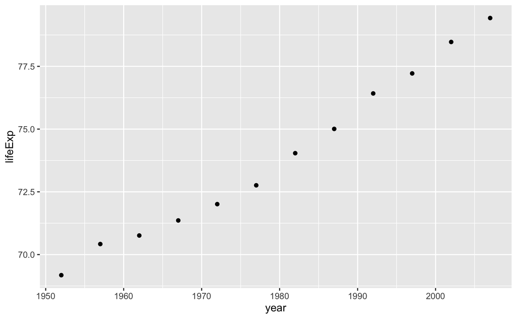

```r
ggplot(uk_data, aes(x = year, y = lifeExp)) + geom_point()
```

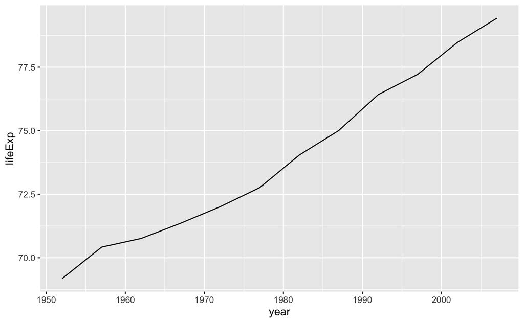

```r
ggplot(uk_data, aes(x = year, y = lifeExp)) + geom_line()
```

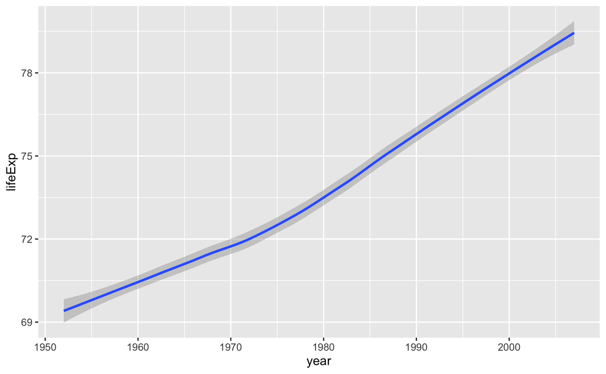

```r
ggplot(uk_data, aes(x = year, y = lifeExp)) + geom_smooth()
```

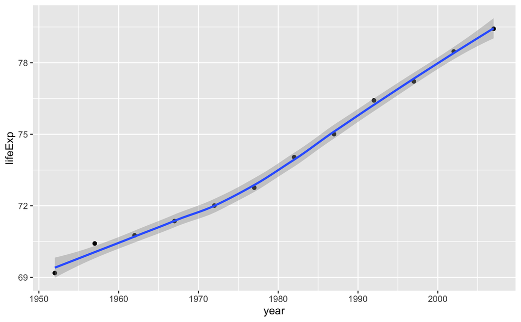

```r
## can combine all plots
ggplot(uk_data, aes(x = year, y = lifeExp)) + geom_point() + geom_smooth()
```

Note: this exercise could also make use of the piping technique

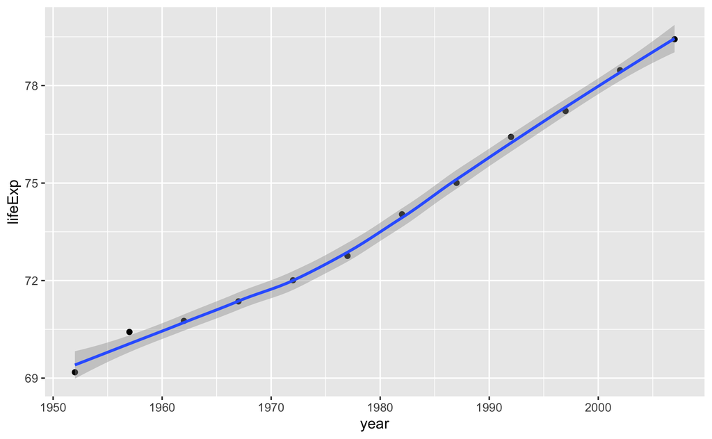

```r
filter(gapminder, country == "United Kingdom") %>%
  ggplot(aes(x = year, y = lifeExp)) + geom_point() + geom_smooth()
```

What happens when you modify the geom_boxplot example to compare the gdp distributions for different years? - Look at the message ggplot2 prints above the plot and try to modify the code to give a separate boxplot for each year

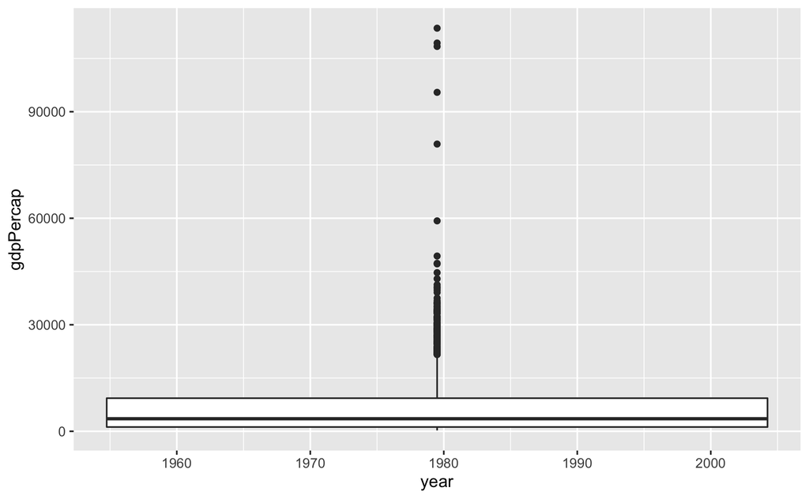

```r
# this is how we might expect the code to look like
ggplot(gapminder, aes(x = year, y = gdpPercap)) + geom_boxplot()
```

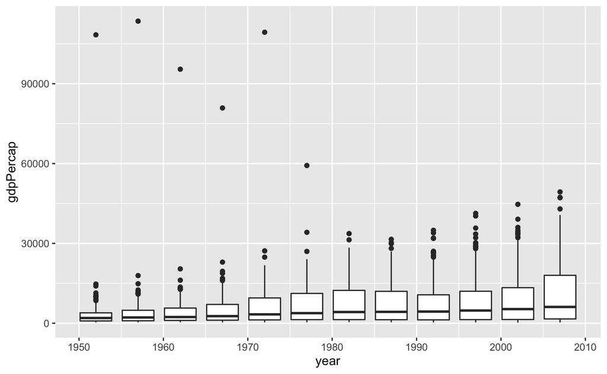

```r
ggplot(gapminder, aes(x = year, y = gdpPercap, group=year)) + geom_boxplot()
```

You will often see this alternative of using the as.factor function to make year into a categorical variable.

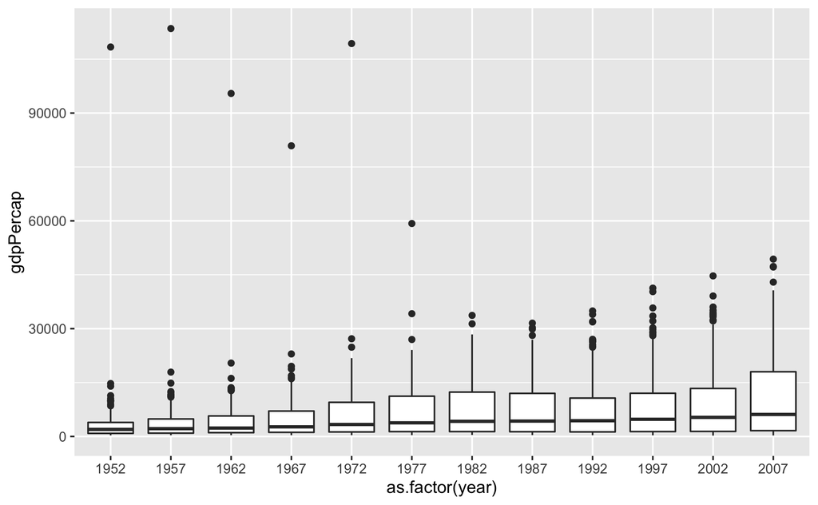

```r
ggplot(gapminder, aes(x = as.factor(year), y = gdpPercap)) + geom_boxplot()
```

## Homework

### Task 1

Add an extra column; the first letter of each country name. Assigning a new variable on each line

```r
gapminder2 <- mutate(gapminder, FirstLetter = substr(country, 1,1))
gapminder3 <- filter(gapminder2, FirstLetter == "Z")
gapminder3
```

| country | continent | year | lifeExp | pop | gdpPercap | FirstLetter |
| --- | --- | --- | --- | --- | --- | --- |
| Zambia | Africa | 1952 | 42.038 | 2672000 | 1147.3888 | Z |
| Zambia | Africa | 1957 | 44.077 | 3016000 | 1311.9568 | Z |
| Zambia | Africa | 1962 | 46.023 | 3421000 | 1452.7258 | Z |
| Zambia | Africa | 1967 | 47.768 | 3900000 | 1777.0773 | Z |
| Zambia | Africa | 1972 | 50.107 | 4506497 | 1773.4983 | Z |
| Zambia | Africa | 1977 | 51.386 | 5216550 | 1588.6883 | Z |
| Zambia | Africa | 1982 | 51.821 | 6100407 | 1408.6786 | Z |
| Zambia | Africa | 1987 | 50.821 | 7272406 | 1213.3151 | Z |
| Zambia | Africa | 1992 | 46.100 | 8381163 | 1210.8846 | Z |
| Zambia | Africa | 1997 | 40.238 | 9417789 | 1071.3538 | Z |

[output cut: 14 more lines]

A more efficient solution

```r
gapminder %>%
  mutate(FirstLetter = substr(country,1,1)) %>%
  filter(FirstLetter == "Z")
```

| country | continent | year | lifeExp | pop | gdpPercap | FirstLetter |
| --- | --- | --- | --- | --- | --- | --- |
| Zambia | Africa | 1952 | 42.038 | 2672000 | 1147.3888 | Z |
| Zambia | Africa | 1957 | 44.077 | 3016000 | 1311.9568 | Z |
| Zambia | Africa | 1962 | 46.023 | 3421000 | 1452.7258 | Z |
| Zambia | Africa | 1967 | 47.768 | 3900000 | 1777.0773 | Z |
| Zambia | Africa | 1972 | 50.107 | 4506497 | 1773.4983 | Z |
| Zambia | Africa | 1977 | 51.386 | 5216550 | 1588.6883 | Z |
| Zambia | Africa | 1982 | 51.821 | 6100407 | 1408.6786 | Z |
| Zambia | Africa | 1987 | 50.821 | 7272406 | 1213.3151 | Z |
| Zambia | Africa | 1992 | 46.100 | 8381163 | 1210.8846 | Z |
| Zambia | Africa | 1997 | 40.238 | 9417789 | 1071.3538 | Z |

[output cut: 14 more lines]

### Task 2 - Heatmap of life expectancy

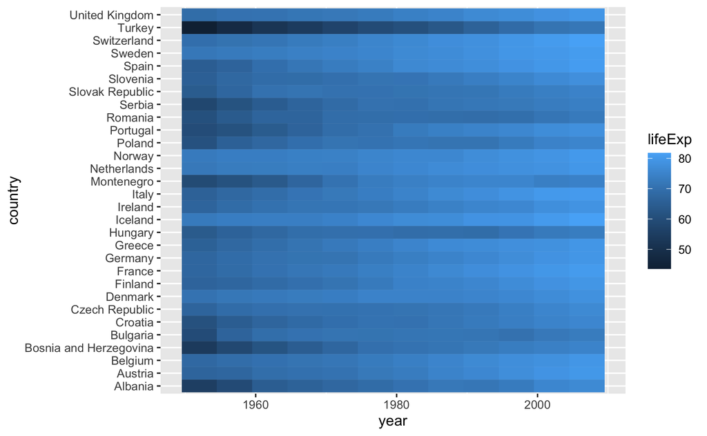

```r
## Get the European countries
filter(gapminder, continent == "Europe") %>%
## make heatmap. See the fill aesthetic to be life expectancy
ggplot(aes(x=year,y=country,fill=lifeExp)) + geom_tile()
```